# Lamb Jaw Length - Heritability estimate and GWAS

Caelinn James

24 March 2021

**Written for R 4.0.2, last updated 31/07/21**

### Load packages

```r
library(RODBC)
library(data.table)
library(stringr)
library(splitstackshape)
library(qqman)
```

### Connect to the database

Note that from database front end version 2.22, it is important to click “Make R Friendly” in the queries section before running the analysis, or loading the pedigree will not work (will not work at all for prior front end versions)

```r
dv <- "C:/Users/s1944058/Documents/Sheep/Database/SoaySheep2.30.accdb"
con <- odbcConnectAccess2007(dv)
tbls <- sqlTables(con)
sheep <- sqlFetch(con,"sys_SheepPlusBirthInfo")
Jaw <- sqlFetch(con,"tblLegJawMeasures")
MuseSumm <- sqlFetch(con,"usys_qMuseumSummary")
```

Check to see if the files have loaded correctly (don’t worry about negative IDs or lots of NAs)…

```r
head(sheep)
```

```
##      ID BirthRef MumSource Status Sex Coat Horn BirthYear BirthMonth BirthDay
## 1 -2644    11143         3  Dummy   2   NA   NA        NA         NA       NA
## 2 -2643       NA        NA  Dummy   2   NA   NA        NA         NA       NA
## 3 -2642    11142         3  Dummy   2   NA   NA        NA         NA       NA
## 4 -2641       NA        NA  Dummy   2   NA   NA        NA         NA       NA
## 5 -2640       NA        NA  Dummy   2   NA   NA        NA         NA       NA
## 6 -2639       NA        NA  Dummy   2   NA   NA        NA         NA       NA
##   MumID BirthWt CapAge BirthEasting BirthNorthing SibCount SibNoObserved TwinID
## 1  4106      NA     NA           NA            NA        0             0     NA
## 2    NA      NA     NA           NA            NA        0             0     NA
## 3 10114      NA     NA           NA            NA        0             0     NA
## 4    NA      NA     NA           NA            NA        0             0     NA
## 5    NA      NA     NA           NA            NA        0             0     NA
## 6    NA      NA     NA           NA            NA        0             0     NA
##   TripletID DeathYear DeathMonth DeathDay DeathType DeathEasting DeathNorthing
## 1        NA        NA         NA       NA        NA           NA            NA
## 2        NA        NA         NA       NA        NA           NA            NA
## 3        NA        NA         NA       NA        NA           NA            NA
## 4        NA        NA         NA       NA        NA           NA            NA
## 5        NA        NA         NA       NA        NA           NA            NA
## 6        NA        NA         NA       NA        NA           NA            NA
##   InCleitDeath
## 1           NA
## 2           NA
## 3           NA
## 4           NA
## 5           NA
## 6           NA
```

```r
head(Jaw)
```

```
##   RowRef StorageRef   Leg    Jaw Measurer MeasureDate Comments
## 1      1        429 72.48  95.97       CD        <NA>     <NA>
## 2      2        430 76.20 100.70       JB        <NA>     <NA>
## 3      3        431 78.61 113.52       JB        <NA>     <NA>
## 4      4        432 68.25  93.73       JB        <NA>     <NA>
## 5      5        433 74.04  96.58       CD        <NA>     <NA>
## 6      6        434 76.41  96.66       JB        <NA>     <NA>
```

```r
head(MuseSumm)
```

```
##     TAG    Sex  Horns BIRTHYEAR DEATHYEAR        DOB BirthYearEstimated
## 1 AO001 Female Polled      2001      2001 2001-04-23                  0
## 2 AO003   Male Normal      2001      2002 2001-04-13                  0
## 3 AO004 Female Normal      2001      2002 2001-04-20                  0
## 4 AO006   Male Normal      2001      2002 2001-04-13                  0
## 5 AO007   Male Normal      2001      2002 2001-04-18                  0
## 6 AO010   Male Normal      2001      2002 2001-04-15                  0
##   BirthMonthEstimated        DOD DeathYearEstimated DeathMonthEstimated
## 1                   0 2001-12-15                  0                   0
## 2                   0 2002-03-29                  0                   0
## 3                   0 2002-02-14                  0                   0
## 4                   0 2002-02-26                  0                   0
## 5                   0 2002-01-15                  0                   0
## 6                   0 2002-03-06                  0                   0
##   AgeatDeath_years AgeatDeath_months StorageRef NationalMuseumCode   ID Horn
## 1                0                 8          1    NMSZ.2003.160.1 4563   NA
## 2                1                11          2    NMSZ.2003.160.2 4565    1
## 3                1                10          3    NMSZ.2003.160.3 4566   NA
## 4                1                10          4    NMSZ.2003.160.4 4568    1
## 5                1                 9          5    NMSZ.2003.160.5 4569    1
## 6                1                11          6    NMSZ.2003.160.7 4571   NA
##   Jaw Leg Skull Tooth
## 1   1   1     1    NA
## 2   1   1     1    NA
## 3   1   1     1    NA
## 4   1   1     1    NA
## 5   1   1     1    NA
## 6   1   1     1    NA
```

### Filter the data

First, we need to match jaw records to sheep IDs

```r
Jaw <- Jaw[-which(Jaw$Comment %like% "DUPLICATE"),]
Jaw <- merge(Jaw,MuseSumm[,1:17],by="StorageRef",all.x=TRUE,all.y=FALSE)
Jaw <- Jaw[,c("ID","Jaw","Leg","AgeatDeath_months")]
```

And only keep sheep we have jaw lengths for

```r
Jaw <- Jaw[!(is.na(Jaw$Jaw)),]
```

Merge the Jaw file with the sheep file

```r
Jaw <- merge(Jaw,sheep,by="ID")
```

```r
Jaw <- Jaw[!(is.na(Jaw$BirthYear)),]
Jaw <- Jaw[!(is.na(Jaw$Sex)),]
Jaw <- Jaw[!(is.na(Jaw$Leg)),]

Jaw <- Jaw[which(Jaw$AgeatDeath_months < 14),]
Jaw <- Jaw[which(Jaw$AgeatDeath_months > 2),]
```

```r
Jaw$ID <- as.factor(Jaw$ID)
Jaw$Sex <- as.factor(Jaw$Sex)
```

```r
SNPs_50K <- read.table("~/Documents/Sheep/50KSNP/Plates_1to87_QC3.fam")
Jaw <- Jaw[which(Jaw$ID %in% SNPs_50K$V2),]
SNPs_HD <- read.table("~/Documents/Sheep/HDSNP/sheep_geno_imputed_oar31_17052020.fam")
Jaw <- Jaw[which(Jaw$ID %in% SNPs_HD$V2),]
```

This leaves us with **2124** individuals, and the following distribution of jaw lengths:

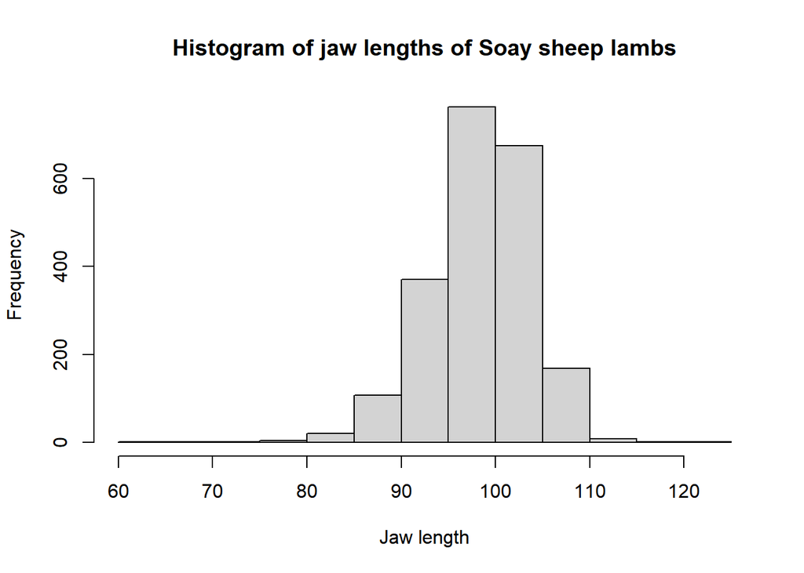

```r
hist(Jaw$Jaw, xlab="Jaw length",main="Histogram of jaw lengths of Soay sheep lambs")
```

We will now save a list of phenotypes, fixed effects and random effects

```r
JawLength_Lamb_LambPhenotypes <- cbind(rep(1,nrow(Jaw)),as.character(Jaw$ID),as.character(Jaw$Jaw))

JawLength_Lamb_LambAssoc <- cbind(rep(1,nrow(Jaw)),as.character(Jaw$ID),Jaw$Sex,Jaw$SibCount)

JawLength_Lamb_LambQAssoc <- cbind(rep(1,nrow(Jaw)),as.character(Jaw$ID),Jaw$AgeatDeath_months)

JawLength_Lamb_LambRandom <-cbind(rep(1,nrow(Jaw)),as.character(Jaw$ID),Jaw$BirthYear)
colnames(JawLength_Lamb_LambRandom) <- c("FID","IID","BirthYear")


write.table(JawLength_Lamb_LambPhenotypes,file="~/Documents/Sheep/R/JawLength/JawLength_LambPhenotypes.txt",row.names = F,col.names = F,quote = F)

write.table(JawLength_Lamb_LambAssoc,file="~/Documents/Sheep/R/JawLength/JawLength_LambAssoc.txt",row.names = F,col.names = F,quote = F)

write.table(JawLength_Lamb_LambQAssoc,file="~/Documents/Sheep/R/JawLength/JawLength_LambQAssoc.txt",row.names = F,col.names = F,quote = F)

write.table(JawLength_Lamb_LambRandom,file="~/Documents/Sheep/R/JawLength/JawLength_LambRandom.txt",row.names = F,col.names = T,quote = F)
```

## Heritability Estimates

### 50K

> #!/bin/sh  
> #$ -cwd  
> #$ -l h_rt=1:00:00  
> #$ -pe sharedmem 1  
> #$ -l h_vmem=100G  
> #$ -M s1944058@sms.ed.ac.uk  
> #$ -m baes  
> . /etc/profile.d/modules.sh

> module load igmm/apps/dissect/1.15.2c  
> module load igmm/apps/plink/1.90b4

> mpirun -np 8 dissect.mpich --reml --bfile ../InputData/Plates_1to87_QC3 --pheno JawLengthPhenotypes.txt --pheno-col 1 --blue --covar JawLengthAssoc.txt --qcovar JawLengthQAssoc.txt --random-effects JawLengthRandom.txt --random-effects-cols 1 2 --out 50K/JawLength_Lamb_50K_H2

> if [[ -f 50K/JawLength_Lamb_50K_H2.badsnps ]]  
> then  
> plink --bfile ../InputData/Plates_1to87_QC3 --sheep --exclude 50K/JawLength_Lamb_50K_H2.badsnps --make-bed --out 50K/JawLength_Lamb_50K_H2

> mpirun -np 8 dissect.mpich --reml --bfile 50K/JawLength_Lamb_50K_H2 --pheno JawLengthPhenotypes.txt --pheno-col 1 --blue --covar JawLengthAssoc.txt --qcovar JawLengthQAssoc.txt --random-effects JawLengthRandom.txt --random-effects-cols 1 2 --out 50K/JawLength_Lamb_50K_H2  
> fi

> mpirun -np 8 dissect.mpich --reml --bfile ../InputData/Plates_1to87_QC3 --pheno JawLengthPhenotypes.txt --pheno-col 1 --blue --random-effects JawLengthRandom.txt --random-effects-cols 1 2 --out 50K/JawLength_Lamb_50K_TotalPhenotypeVariance

> if [[ -f 50K/JawLength_Lamb_50K_TotalPhenotypeVariance.badsnps ]]  
> then  
> plink --bfile ../InputData/Plates_1to87_QC3 --sheep --exclude 50K/JawLength_Lamb_50K_TotalPhenotypeVariance.badsnps --make-bed --out 50K/JawLength_Lamb_50K_TotalPhenotypeVariance

> mpirun -np 8 dissect.mpich --reml --bfile 50K/JawLength_Lamb_50K_TotalPhenotypeVariance --pheno JawLengthPhenotypes.txt --pheno-col 1 --blue --random-effects JawLengthRandom.txt --random-effects-cols 1 2 --out 50K/JawLength_Lamb_50K_TotalPhenotypeVariance  
> fi

```r
FixedEffects_50K
```

```
##           NAME     BETA       STD
## 1          Sex  1.89846 0.1858190
## 2        Twins -2.22938 0.2290930
## 3     Triplets -1.37769 4.1806800
## 4 Age at death  2.17205 0.0779952
```

```r
RandomEffects_50K
```

```
##                            NAME     BETA      STD
## 1:                  Var(GRM_p1)  6.03674 0.795703
## 2:            Var(BirthYear_p1) 0.983533 0.373482
## 3:                    Var(E_p1)  12.8403 0.669889
## 4: Var(GRM_p1)/Var(Phenotype_1) 0.303955 0.035862
```

### HD

> #!/bin/sh  
> #$ -cwd  
> #$ -l h_rt=1:00:00  
> #$ -pe sharedmem 1  
> #$ -l h_vmem=100G  
> #$ -M s1944058@sms.ed.ac.uk  
> #$ -m baes  
> . /etc/profile.d/modules.sh

> module load igmm/apps/dissect/1.15.2c  
> module load igmm/apps/plink/1.90b4

> mpirun -np 8 dissect.mpich --reml --bfile ../InputData/sheep_geno_imputed_oar31_17052020 --pheno JawLengthPhenotypes.txt --pheno-col 1 --blue --covar JawLengthAssoc.txt --qcovar JawLengthQAssoc.txt --random-effects JawLengthRandom.txt --random-effects-cols 1 2 --out HD/JawLength_Lamb_HD_H2

> if [[ -f HD/JawLength_Lamb_HD_H2.badsnps ]]  
> then  
> plink --bfile ../InputData/sheep_geno_imputed_oar31_17052020 --sheep --exclude HD/JawLength_Lamb_HD_H2.badsnps --make-bed --out HD/JawLength_Lamb_HD_H2

> mpirun -np 8 dissect.mpich --reml --bfile HD/JawLength_Lamb_HD_H2 --pheno JawLengthPhenotypes.txt --pheno-col 1 --blue --covar JawLengthAssoc.txt --qcovar JawLengthQAssoc.txt --random-effects JawLengthRandom.txt --random-effects-cols 1 2 --out HD/JawLength_Lamb_HD_H2  
> fi

> mpirun -np 8 dissect.mpich --reml --bfile ../InputData/sheep_geno_imputed_oar31_17052020 --pheno JawLengthPhenotypes.txt --pheno-col 1 --blue --random-effects JawLengthRandom.txt --random-effects-cols 1 2 --out HD/JawLength_Lamb_HD_TotalPhenotypeVariance

> if [[ -f HD/JawLength_Lamb_HD_TotalPhenotypeVariance.badsnps ]]  
> then  
> plink --bfile ../InputData/sheep_geno_imputed_oar31_17052020 --sheep --exclude HD/JawLength_Lamb_HD_TotalPhenotypeVariance.badsnps --make-bed --out HD/JawLength_Lamb_HD_TotalPhenotypeVariance

> mpirun -np 8 dissect.mpich --reml --bfile HD/JawLength_Lamb_HD_TotalPhenotypeVariance --pheno JawLengthPhenotypes.txt --pheno-col 1 --blue --random-effects JawLengthRandom.txt --random-effects-cols 1 2 --out HD/JawLength_Lamb_HD_TotalPhenotypeVariance  
> fi

```r
FixedEffects_HD
```

```
##           NAME     BETA       STD
## 1          Sex  1.85497 0.1821460
## 2        Twins -2.23109 0.2296040
## 3     Triplets -1.33519 4.1987300
## 4 Age at death  2.17526 0.0779826
```

```r
RandomEffects_HD
```

```
##                            NAME     BETA       STD
## 1:                  Var(GRM_p1)  6.25589  0.818506
## 2:            Var(BirthYear_p1) 0.985329  0.374117
## 3:                    Var(E_p1)  12.6477  0.678725
## 4: Var(GRM_p1)/Var(Phenotype_1) 0.314541 0.0366972
```

### GWAS

> #!/bin/sh  
> #$ -cwd  
> #$ -l h_rt=2:00:00  
> #$ -pe sharedmem 1  
> #$ -l h_vmem=200G  
> #$ -t 1-26  
> #$ -tc 5  
> #$ -M s1944058@sms.ed.ac.uk  
> #$ -m baes  
> . /etc/profile.d/modules.sh

> module load igmm/apps/dissect/1.15.2c  
> module load igmm/apps/plink/1.90b4

> i=$_TASK_ID

> plink --bfile ../InputData/Plates_1to87_QC3 --sheep --not-chr ${i},X --keep JawLengthPhenotypes.txt --make-bed --out 50K/NoChr${i}

> mpirun -np 8 dissect.mpich --make-grm --bfile 50K/NoChr${i} --out 50K/NoChr${i}_GRM

> echo "50K/Chr${i} 50K/NoChr${i}_GRM" > 50K/GWAS_GRM${i}.txt

> plink --bfile ../InputData/Plates_1to87_QC3 --sheep --chr ${i} --keep JawLengthPhenotypes.txt --make-bed --out 50K/Chr${i}

> if [[ -f 50K/NoChr${i}_GRM.badsnps ]]  
> then  
> plink --bfile 50K/NoChr${i} --sheep --exclude 50K/NoChr${i}_GRM.badsnps --make-bed --out 50K/NoChr${i}_2

> mpirun -np 8 dissect.mpich --make-grm --bfile 50K/NoChr${i}_2 --out 50K/NoChr${i}_GRM

> fi

> mpirun -np 8 dissect.mpich --gwas --bfile-grm-list 50K/GWAS_GRM${i}.txt --pheno JawLengthPhenotypes.txt --covar JawLengthAssoc.txt --qcovar JawLengthQAssoc.txt --random-effects JawLengthRandom.txt --random-effects-cols 1,2 --out 50K/JawLength_Lamb_50K_GWAS_Chr${i}

> if [[ -f 50K/JawLength_Lamb_50K_GWAS_Chr${i}.badsnps ]]  
> then  
> plink --bfile 50K/Chr${i} --sheep --exclude 50K/JawLength_Lamb_50K_GWAS_Chr${i}.badsnps --make-bed --out 50K/Chr${i}_2

> echo "50K/Chr${i}_2 50K/NoChr${i}_GRM" > 50K/GWAS_GRM${i}.txt

> mpirun -np 8 dissect.mpich --gwas --bfile-grm-list 50K/GWAS_GRM${i}.txt --pheno JawLengthPhenotypes.txt --covar JawLengthAssoc.txt --qcovar JawLengthQAssoc.txt --random-effects JawLengthRandom.txt --random-effects-cols 1,2 --out 50K/JawLength_Lamb_50K_GWAS_Chr${i}  
> fi

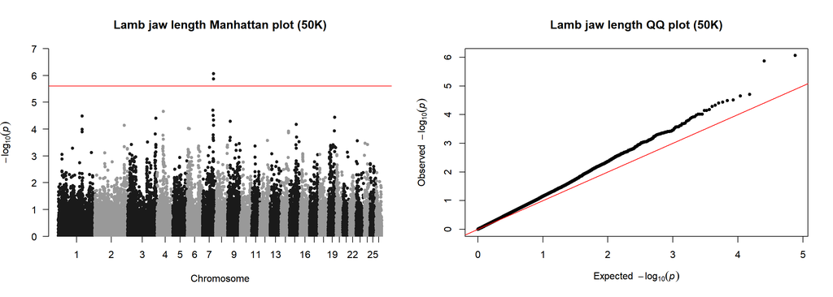

```r
files = list.files(pattern="JawLength_Lamb_50K_GWAS_Chr",recursive=TRUE)

SNPresults = do.call(rbind, lapply(files, function(x) read.table(x,header=T)))
SNPresults$Effect <- SNPresults$STDEV*SNPresults$STDEV*SNPresults$BETA*SNPresults$BETA

bimFile <- read.table("C:/Users/s1944058/Documents/Sheep/50KSNP/Plates_1to87_QC3.bim",header=F)

GWAS50KResults <- merge(bimFile,SNPresults[,c("SNP","PV","Effect"),],by.x="V2",by.y="SNP",all.x=FALSE,all.y=TRUE)
colnames(GWAS50KResults) <- c("SNP","Chr","V3","Pos","Ref","Minor","PV","Effect")
GWAS50KResults$Chr <- as.numeric(GWAS50KResults$Chr)
par(mfrow=c(1,2))
manhattan(GWAS50KResults,chr="Chr",bp="Pos",p="PV",snp="SNP", main = "Lamb jaw length Manhattan plot (50K)", genomewideline = -log10(0.05/20082),suggestiveline = FALSE)
qq(GWAS50KResults$PV,main="Lamb jaw length QQ plot (50K)")
```

```r
SNPs <- GWAS50KResults[which(GWAS50KResults$PV < (0.05/20082) ),c("Chr","Pos","SNP","PV","Effect")]
SNPs[order(SNPs$PV),]
```

```
##       Chr      Pos               SNP         PV    Effect
## 37666   7 82851545          s73063.1 8.7128e-07 0.1346640
## 23929   7 82749607 OAR7_90115917_X.1 1.3643e-06 0.1049365
```

### Imputed SNP data

> #!/bin/sh  
> #$ -cwd  
> #$ -l h_rt=3:00:00  
> #$ -pe sharedmem 1  
> #$ -l h_vmem=200G  
> #$ -t 1-26  
> #$ -tc 5  
> #$ -M s1944058@sms.ed.ac.uk  
> #$ -m baes  
> . /etc/profile.d/modules.sh

> module load igmm/apps/dissect/1.15.2c  
> module load igmm/apps/plink/1.90b4

> i=$_TASK_ID

> plink --bfile ../InputData/sheep_geno_imputed_oar31_17052020 --sheep --not-chr ${i},X --keep JawLengthPhenotypes.txt --make-bed --out HD/NoChr${i}

> mpirun -np 8 dissect.mpich --make-grm --bfile HD/NoChr${i} --out HD/NoChr${i}_GRM

> echo "HD/Chr${i} HD/NoChr${i}_GRM" > HD/GWAS_GRM${i}.txt

> plink --bfile ../InputData/sheep_geno_imputed_oar31_17052020 --sheep --chr ${i} --keep JawLengthPhenotypes.txt --make-bed --out HD/Chr${i}

> if [[ -f HD/NoChr${i}_GRM.badsnps ]]  
> then  
> plink --bfile HD/NoChr${i} --sheep --exclude HD/NoChr${i}_GRM.badsnps --make-bed --out HD/NoChr${i}_2

> mpirun -np 8 dissect.mpich --make-grm --bfile HD/NoChr${i}_2 --out HD/NoChr${i}_GRM

> fi

> mpirun -np 8 dissect.mpich --gwas --bfile-grm-list HD/GWAS_GRM${i}.txt --pheno JawLengthPhenotypes.txt --covar JawLengthAssoc.txt --qcovar JawLengthQAssoc.txt --random-effects JawLengthRandom.txt --random-effects-cols 1,2 --out HD/JawLength_Lamb_HD_GWAS_Chr${i}

> if [[ -f HD/JawLength_Lamb_HD_GWAS_Chr${i}.badsnps ]]  
> then  
> plink --bfile HD/Chr${i} --sheep --exclude HD/JawLength_Lamb_HD_GWAS_Chr${i}.badsnps --make-bed --out HD/Chr${i}_2

> echo "HD/Chr${i}_2 HD/NoChr${i}_GRM" > HD/GWAS_GRM${i}.txt

> mpirun -np 8 dissect.mpich --gwas --bfile-grm-list HD/GWAS_GRM${i}.txt --pheno JawLengthPhenotypes.txt --covar JawLengthAssoc.txt --qcovar JawLengthQAssoc.txt --random-effects JawLengthRandom.txt --random-effects-cols 1,2 --out HD/JawLength_Lamb_HD_GWAS_Chr${i}  
> fi

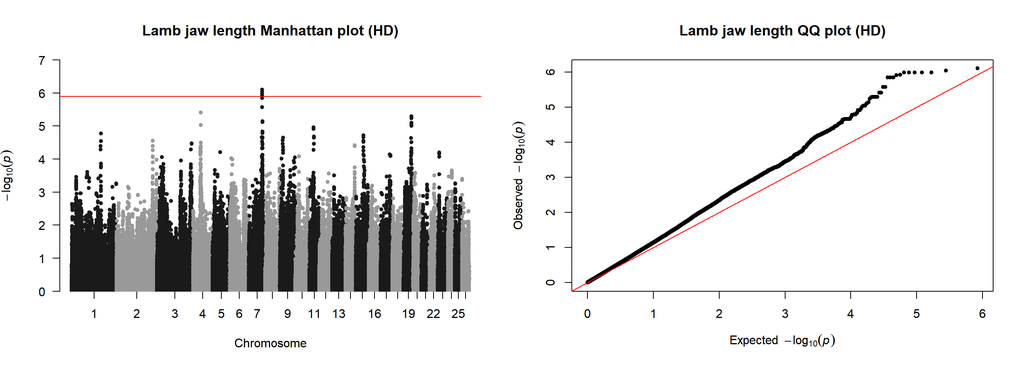

```r
files = list.files(pattern="JawLength_Lamb_HD_GWAS_Chr",recursive=TRUE)

SNPresults = do.call(rbind, lapply(files, function(x) read.table(x,header=T)))
SNPresults$Effect <- SNPresults$STDEV*SNPresults$STDEV*SNPresults$BETA*SNPresults$BETA

bimFile <- read.table("C:/Users/s1944058/Documents/Sheep/HDSNP/sheep_geno_imputed_oar31_17052020.bim",header=F)

GWASHDResults <- merge(bimFile,SNPresults[,c("SNP","PV","Effect"),],by.x="V2",by.y="SNP",all.x=FALSE,all.y=TRUE)
colnames(GWASHDResults) <- c("SNP","Chr","V3","Pos","Ref","Minor","PV","Effect")
GWASHDResults$Chr <- as.numeric(GWASHDResults$Chr)
par(mfrow=c(1,2))
manhattan(GWASHDResults,chr="Chr",bp="Pos",p="PV",snp="SNP", main = "Lamb jaw length Manhattan plot (HD)", genomewideline = -log10(0.05/39149),suggestiveline = FALSE)
qq(GWASHDResults$PV,main="Lamb jaw length QQ plot (HD)")
```

```r
SNPs <- GWASHDResults[which(GWASHDResults$PV < (0.05/39149) ),c("Chr","Pos","SNP","PV","Effect")]
SNPs[order(SNPs$PV),]
```

```
##        Chr      Pos                SNP         PV    Effect
## 418273   7 82851545           s73063.1 7.9164e-07 0.1361344
## 366638   7 82806441 oar3_OAR7_82806441 9.2030e-07 0.1081752
## 366636   7 82797103 oar3_OAR7_82797103 1.0252e-06 0.1069983
## 366637   7 82797163 oar3_OAR7_82797163 1.0252e-06 0.1069983
## 366639   7 82812147 oar3_OAR7_82812147 1.0390e-06 0.1069983
## 366641   7 82821933 oar3_OAR7_82821933 1.0390e-06 0.1069983
## 366643   7 82830554 oar3_OAR7_82830554 1.0390e-06 0.1069983
## 366645   7 82846831 oar3_OAR7_82846831 1.1852e-06 0.1057167
## 404177   7 82749607  OAR7_90115917_X.1 1.2253e-06 0.1061079
```

## **FINAL RESULTS**

### 50K

```r
RandomEffects_50K[nrow(RandomEffects_50K),]
```

```
##                            NAME     BETA      STD
## 1: Var(GRM_p1)/Var(Phenotype_1) 0.303955 0.035862
```

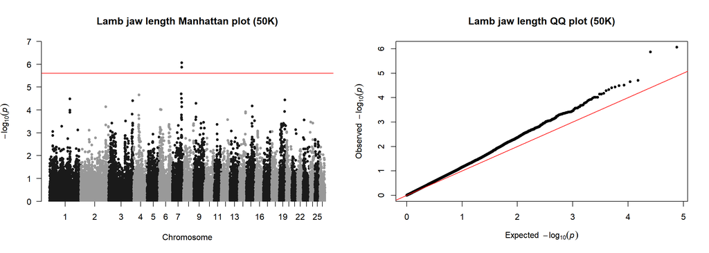

```r
par(mfrow=c(1,2))
manhattan(GWAS50KResults,chr="Chr",bp="Pos",p="PV",snp="SNP", main = "Lamb jaw length Manhattan plot (50K)", genomewideline = -log10(0.05/20082),suggestiveline = FALSE)
qq(GWAS50KResults$PV,main="Lamb jaw length QQ plot (50K)")
```

### HD

```r
RandomEffects_HD[nrow(RandomEffects_HD),]
```

```
##                            NAME     BETA       STD
## 1: Var(GRM_p1)/Var(Phenotype_1) 0.314541 0.0366972
```

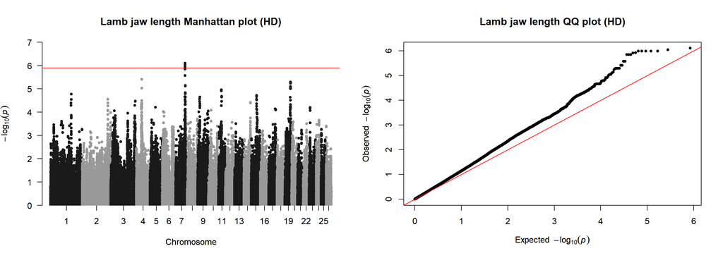

```r
par(mfrow=c(1,2))
manhattan(GWASHDResults,chr="Chr",bp="Pos",p="PV",snp="SNP", main = "Lamb jaw length Manhattan plot (HD)", genomewideline = -log10(0.05/39149),suggestiveline = FALSE)
qq(GWASHDResults$PV,main="Lamb jaw length QQ plot (HD)")
```